# Bayesian GLM Part2

Author

Murray Logan

Published

19/08/2026

# 1 Preparations

Load the necessary libraries

```r
library(tidyverse)     #for data wrangling etc
library(cmdstanr)      #for cmdstan
library(brms)          #for fitting models in STAN
library(coda)          #for diagnostics
library(bayesplot)     #for diagnostics
library(DHARMa)        #for residual diagnostics
library(rstan)         #for interfacing with STAN
library(emmeans)       #for marginal means etc
library(broom)         #for tidying outputs
library(tidybayes)     #for more tidying outputs
library(broom.mixed)   #for summarising models
library(bayestestR)    #for ROPE
library(easystats)     #for the easystats ecosystem
library(ggeffects)
library(patchwork)     #for multiple plots
theme_set(theme_grey()) #put the default ggplot theme back
source("helperFunctions.R")
```

# 2 Scenario

Polis et al. (1998) were interested in modelling the presence/absence of lizards (*Uta sp.*) against the perimeter to area ratio of 19 islands in the Gulf of California.

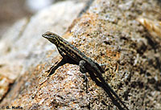

**Figure** 1: Uta lizard

**Table** 1: Format of polis.csv data file

| ISLAND | RATIO | PA |
| --- | --- | --- |
| Bota | 15.41 | 1 |
| Cabeza | 5.63 | 1 |
| Cerraja | 25.92 | 1 |
| Coronadito | 15.17 | 0 |
| .. | .. | .. |

**Table** 2: Description of the variables in the polis data file

| **ISLAND** | Categorical listing of the name of the 19 islands used - variable not used in analysis. |
| --- | --- |
| **RATIO** | Ratio of perimeter to area of the island. |
| **PA** | Presence (1) or absence (0) of *Uta* lizards on island. |

The aim of the analysis is to investigate the relationship between island perimeter to area ratio and the presence/absence of Uta lizards.

# 3 Read in the data

```r
polis <- read_csv("../data/polis.csv", trim_ws = TRUE)
```

# 4 Bernoulli distribution

Bernoulli is a special case of binomial.

# 5 Exploratory data analysis

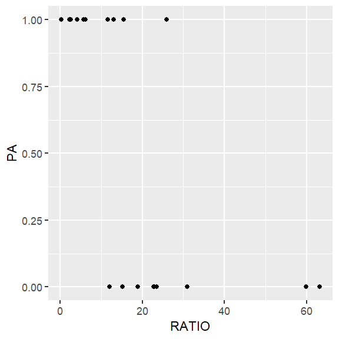

```r
polis |>
  ggplot(aes(y = PA, x = RATIO)) +
  geom_point()
```

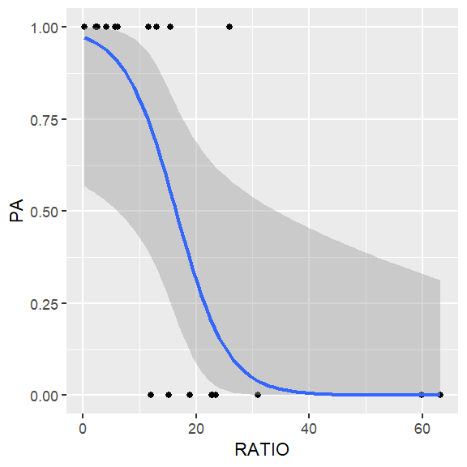

```r
#higher presence of lizards when island ration is small

#now add in curve to show the Bernoulli shape
polis |>
  ggplot(aes(y = PA, x = RATIO)) +
  geom_point() +
  geom_smooth(method='glm', formula=y~x,
              method.args=list(family='binomial'))
```

The individual responses ($y_i$, observed presence/absence of Uta lizards) are each expected to have been **independently** drawn from Bernoulli (or binomial) distributions ($\mathcal{Bin}$). These distributions represent all the possible presence/absences we could have obtained at the specific ($i^th$) level of island perimeter to area ratio. Hence the $i^th$ presence/absence observation is expected to have been drawn from a binomial distribution with a probability of $\mu_i$ and size of ($n=1$).

The expected probabilities are related to the linear predictor (intercept plus slope associated with perimeter to area ratio) via a **logit** link.

We need to supply priors for each of the parameters to be estimated ($\beta_0$ and $\beta_1$). Whilst we want these priors to be sufficiently vague as to not influence the outcomes of the analysis (and thus be equivalent to the frequentist analysis), we do not want the priors to be so vague (wide) that they permit the MCMC sampler to drift off into parameter space that is both illogical as well as numerically awkward.

As a starting point, lets assign the following priors:

Model formula:
$$\begin{align}
y_i &\sim{} \mathcal{Bin}(n, \pi_i)\\
OR \\
y_i &\sim{} \mathcal{Bernoulli}(\pi_i)\\
ln\left(\frac{\pi_i}{1-\pi_i}\right) &= \beta_0 + \beta_1 x_i\\
\beta_0 &\sim{} \mathcal{N}(0, 1)\\
\beta_1 &\sim{} \mathcal{N}(0, 1)\\
\end{align}$$